## Alexis AURISSERGUES, Adnane EL KASMI, Sébastien IBRAHIM, Grégoire RÉMY

### ISUP, M2 ISDS

# Projet Machine Learning : Analyse statistique de la biodégradabilité des composants chimiques

Parmi les nombreuses problématiques écologiques aujourd'hui cruciales pour l'avenir, une des plus importantes est celle de la pollution des environnements naturels par l'activité humaine. À ce titre, la question de la biodégradabilité des composants utilisés dans l'industrie est essentielle.

Nous nous sommes donc penchés sur ce sujet pour ce projet, et avons décidé de travailler sur la base de données **"QSAR biodegradation"** (cf https://archive.ics.uci.edu/ml/datasets/QSAR+biodegradation#), dataset élaboré par un groupe de chercheurs en chimie de l'université de Milan.

Ce jeu de données consiste en un tableau de 1054 individus, qui sont des composants chimiques. Une variable appelée "experimental_class" distingue les composants selon s'ils sont **biodégradables** ou non (le caractère biodégradable a été établi par les chimistes selon un protocole expérimental en laboratoire, d'où le nom de la variable). 41 autres variables représentent diverses propriétés physico-chimiques des éléments étudiés.

L'objectif de ce projet est d'expliquer le caractère biodégradable / non-biodégradable des composants en fonction des autres variables. Il s'agit donc d'un problème de **classification supervisée** (binaire), pour lequel nous appliquerons et comparerons différents modèles.

# Plan de l'étude :

- I. Travail préliminaire avant la modélisation
  - I.1. Bibliothèques, fonctions d'évaluation des modèles, scores étudiés
  - I.2. Import des données
  - I.3. Nettoyage
  - I.4. Analyse exploratoire
    - I.4.a. Déséquilibre des classes
    - I.4.b. Matrice des corrélations
    - I.4.c. Variables séparant le mieux les classes
  - I.5. Data processing
  - I.6. Découpage en sets d'entraînement et de test
  - I.7. Mise à l'échelle
    - I.7.a. Données normalisées
    - I.7.b. Transformation B-spline
  - I.8. Sélection des variables
    - I.8.a. Première étape de sélection : régression logistique avec pénalité lasso
    - I.8.b. Seconde étape de sélection : random forest
- II. Modélisation
  - II.1. Régression logistique
  - II.2. Random forest
  - II.3. K plus proches voisins
  - II.4. SVM linéaire
  - II.5. Adaboost
  - II.6. Perceptron multicouche
  - II.7. Voting classifier
- III. Sélection du meilleur modèle, optimisation et validation
  - III.1. Sélection du meilleur modèle
  - III.2. Optimisation
  - III.3. Modèle final
- IV. Conclusion

# Travail préliminaire avant la modélisation

## Bibliothèques, fonctions d'évaluation des modèles, scores étudiés

On importe les bibliothèques nécessaires :

```python
import pandas as pd
from sklearn.preprocessing import LabelEncoder, OrdinalEncoder
import numpy as np
import matplotlib.pyplot as plt
import seaborn as sns
from sklearn.preprocessing import StandardScaler
from sklearn.model_selection import train_test_split
import sklearn.metrics as metrics
from sklearn.linear_model import LogisticRegression
import numpy as np
from sklearn.feature_selection import RFE
from sklearn.ensemble import RandomForestRegressor
from sklearn import metrics
import seaborn as sn
from matplotlib.pyplot import figure
from sklearn.ensemble import RandomForestClassifier
from sklearn.preprocessing import SplineTransformer
import pandas
from sklearn.neighbors import KNeighborsRegressor
from sklearn.model_selection import GridSearchCV
from sklearn.metrics import r2_score
from sklearn.metrics import make_scorer

from sklearn.metrics import confusion_matrix
import warnings
warnings.filterwarnings("ignore")
```

On crée des fonctions pour évaluer nos modèles :

```python
def model_score(y,y_pred):         #Fonction qui renvoie plusieurs statistiques entre nos prédictions et nos données tests
    acc = metrics.accuracy_score(y,y_pred)
    prec = metrics.precision_score(y,y_pred)
    sens = metrics.recall_score(y,y_pred)
    f_1 = 2*(prec*sens)/(prec+sens)
    print('Accuracy:', np.round(acc,2))
    print('Précision:', np.round(prec,2))
    print('Sensitivité:',np.round(sens,2))
    print('F1:', np.round(f_1,2))
    return

def matrice_conf(y,y_pred):             #Affiche la matrice de confusion
    cf=confusion_matrix(y,y_pred)
    sns.heatmap(cf,annot=True,cmap='Greens',fmt='g')
    return

def learning_curve_nn(history):           #learning curve pour les réseaux de neurones
    plt.plot(history.history['accuracy'])
    plt.title('model accuracy')
    plt.ylabel('accuracy')
    plt.xlabel('epoch')
    plt.show()

    plt.plot(history.history['loss'])
    plt.title('model loss')
    plt.ylabel('loss')
    plt.xlabel('epoch')
    plt.show()

def recap_model(dict_model,y):
    res=pd.DataFrame(index=list(dict_model.keys()))
    accu=[]
    prec=[]
    sens=[]
    f_1=[]
    somme=[]
    for key in dict_model.keys():
        a = metrics.accuracy_score(y,dict_model[key])
        p = metrics.precision_score(y,dict_model[key])
        s = metrics.recall_score(y,dict_model[key])
        f = 2*(p*s)/(p+s)

        accu.append(np.round(a,2))
        prec.append(np.round(p,2))
        f_1.append(np.round(f,2))
        sens.append(np.round(s,2))
    for i in range(len(accu)):
        somme.append(accu[i]+prec[i]+sens[i]+f_1[i])
    res["Accuracy"]=accu
    res["Precision"]=prec
    res["Sensitivity"]=sens
    res["Score F1"]=f_1
    res["Somme"]=somme

    res=res.sort_values(by = "Somme", ascending = False)
    return res
```

Pour vérifier la qualité des modèles que nous utiliserons, nous calculerons à chaque fois avec la fonction model_score ci-dessus différents scores :

- L'**Accuracy** ou taux de succès : proportion des composants correctement classés par le modèle.
- La **Précision** : proportion, parmi les composants classés comme biodégradables par le modèle, de ceux qui sont bien biodégradables
- La **Sensibilité** : proportion, parmi les composants biodégradables, de ceux qui ont bien été classés comme biodégradables par le modèle.
- Le score **F1** est la moyenne harmonique de la précision et de la sensibilité.

La précision donne donc le taux de vrais positifs parmi tous les composants classés comme "positifs" (biodégradables). Étudier ce score est donc particulièrement adapté ici, car nous sommes dans une situation où l'on veut éviter au maximum les faux positifs. En effet, un faux positif signifie ici considérer comme biodégradable un composant qui ne l'est pas, ce qui peut amener à des pollutions graves.

## Import des données

On importe notre base de données.

```python
raw_df = pd.read_csv("C:/Users/M86887/Downloads/biodeg.csv",sep=';')
```

Le nom des variables n'étant pas renseigné, on les ajoute manuellement en se basant sur les informations de la page web où nous avons trouvé le dataset :

```python
col = ["SpMax_L", "J_Dz(e)","nHM","F01[N-N]","F04[C-N]","NssssC","nCb-","C%","nCp","nO", "F03[C-N]","SdssC",
"HyWi_B(m)","LOC","SM6_L","F03[C-O]","Me","Mi","nN-N","nArNO2","nCRX3","SpPosA_B(p)","nCIR","B01[C-Br]",
    "B03[C-Cl]","N-073","SpMax_A","Psi_i_1d","B04[C-Br]","SdO","TI2_L","nCrt","C-026","F02[C-N]",
"nHDon","SpMax_B(m)","Psi_i_A","nN","SM6_B(m)","nArCOOR","nX","experimental_class"]
```

```python
raw_df.columns = col
raw_df
```

|  | SpMax_L | J_Dz(e) | nHM | F01[N-N] | F04[C-N] | NssssC | nCb- | C% | nCp | nO | ... | C-026 | F02[C-N] | nHDon | SpMax_B(m) | Psi_i_A | nN | SM6_B(m) | nArCOOR | nX | experimental_class |
| --- | --- | --- | --- | --- | --- | --- | --- | --- | --- | --- | --- | --- | --- | --- | --- | --- | --- | --- | --- | --- | --- |
| 0 | 4.17 | 2.11 | 0 | 0 | 0 | 0 | 0 | 30.80 | 1 | 1 | ... | 0 | 0 | 0 | 3.31 | 1.97 | 0 | 7.26 | 0 | 0 | RB |
| 1 | 3.93 | 3.25 | 0 | 0 | 0 | 0 | 0 | 26.70 | 2 | 4 | ... | 0 | 0 | 1 | 3.08 | 2.42 | 0 | 7.60 | 0 | 0 | RB |
| 2 | 3.00 | 2.71 | 0 | 0 | 0 | 0 | 0 | 20.00 | 0 | 2 | ... | 0 | 0 | 1 | 3.05 | 5.00 | 0 | 6.69 | 0 | 0 | RB |
| 3 | 4.24 | 3.39 | 0 | 0 | 0 | 0 | 0 | 29.40 | 2 | 4 | ... | 0 | 0 | 0 | 3.35 | 2.40 | 0 | 8.00 | 0 | 0 | RB |
| 4 | 4.24 | 3.43 | 0 | 0 | 0 | 0 | 0 | 28.60 | 2 | 4 | ... | 0 | 0 | 0 | 3.35 | 2.56 | 0 | 7.90 | 0 | 0 | RB |
| ... | ... | ... | ... | ... | ... | ... | ... | ... | ... | ... | ... | ... | ... | ... | ... | ... | ... | ... | ... | ... | ... |
| 1049 | 5.43 | 2.90 | 0 | 0 | 0 | 2 | 0 | 32.10 | 4 | 1 | ... | 0 | 6 | 1 | 3.57 | 2.24 | 1 | 8.09 | 0 | 0 | NRB |
| 1050 | 5.29 | 3.37 | 0 | 0 | 9 | 0 | 0 | 35.30 | 0 | 9 | ... | 0 | 3 | 0 | 3.79 | 3.08 | 3 | 9.28 | 0 | 0 | NRB |
| 1051 | 4.87 | 1.77 | 0 | 1 | 9 | 0 | 5 | 44.40 | 0 | 4 | ... | 4 | 13 | 0 | 3.85 | 2.58 | 5 | 9.54 | 1 | 0 | NRB |
| 1052 | 5.16 | 1.69 | 2 | 0 | 36 | 0 | 9 | 56.10 | 0 | 0 | ... | 1 | 16 | 0 | 5.81 | 2.06 | 8 | 11.05 | 0 | 1 | NRB |
| 1053 | 5.08 | 2.66 | 2 | 0 | 0 | 0 | 4 | 54.50 | 0 | 0 | ... | 2 | 0 | 0 | 4.01 | 2.21 | 0 | 9.13 | 0 | 2 | NRB |

1054 rows × 42 columns

## Nettoyage des données

Dans cette partie nous allons nous assurer que les données sont complètes, cohérentes et exploitables pour une modélisation

Regardons le type de chaque variable :

```python
raw_df.info()
```

```
<class 'pandas.core.frame.DataFrame'>
RangeIndex: 1054 entries, 0 to 1053
Data columns (total 42 columns):
 #   Column              Non-Null Count  Dtype
---  ------              --------------  -----
 0   SpMax_L             1054 non-null   float64
 1   J_Dz(e)             1054 non-null   float64
 2   nHM                 1054 non-null   int64
 3   F01[N-N]            1054 non-null   int64
 4   F04[C-N]            1054 non-null   int64
 5   NssssC              1054 non-null   int64
 6   nCb-                1054 non-null   int64
 7   C%                  1054 non-null   float64
 8   nCp                 1054 non-null   int64
 9   nO                  1054 non-null   int64
```

[output cut: 34 more lines]

Toutes les variables sont des données numériques (flottants ou entiers) à l'exception de la variables experimental_class qui est une chaîne de caractère. On modifie la variable cible experimental_class en changeant les caractères par des entiers : **si un composant est biodégradable on lui assigne la valeur 1 pour la variable cible, sinon on lui assigne la valeur 0**

```python
df = raw_df.replace(to_replace = 'RB',value = 1)
df = df.replace(to_replace = 'NRB',value = 0)
pd.DataFrame(df["experimental_class"])
```

|  | experimental_class |
| --- | --- |
| 0 | 1 |
| 1 | 1 |
| 2 | 1 |
| 3 | 1 |
| 4 | 1 |
| ... | ... |
| 1049 | 0 |
| 1050 | 0 |
| 1051 | 0 |
| 1052 | 0 |
| 1053 | 0 |

1054 rows × 1 columns

Avec la ligne de code suivante, on vérifie la présence de lignes incomplètes dans notre dataset : pour chaque varriable, on vérifie si tous les individus ont bien une valeur pour cette variable.

```python
df.isna().sum()
```

```
SpMax_L               0
J_Dz(e)               0
nHM                   0
F01[N-N]              0
F04[C-N]              0
                     ..
nN                    0
SM6_B(m)              0
nArCOOR               0
nX                    0
experimental_class    0
Length: 42, dtype: int64
```

C'est bon : pas de données manquantes.

## Analyse exploratoire des données

Le but de cette partie est de mieux comprendre les données et de trouver quelles sont les variables qui expliquent le mieux notre cible. On commence par vérifier s'il existe un déséquilibre entre les classes de notre variable cible :

```python
pd.set_option("display.float", "{:.2f}".format)
df.describe()
```

|  | SpMax_L | J_Dz(e) | nHM | F01[N-N] | F04[C-N] | NssssC | nCb- | C% | nCp | nO | ... | C-026 | F02[C-N] | nHDon | SpMax_B(m) | Psi_i_A | nN | SM6_B(m) | nArCOOR | nX | experimental_class |
| --- | --- | --- | --- | --- | --- | --- | --- | --- | --- | --- | --- | --- | --- | --- | --- | --- | --- | --- | --- | --- | --- |
| count | 1054.00 | 1054.00 | 1054.00 | 1054.00 | 1054.00 | 1054.00 | 1054.00 | 1054.00 | 1054.00 | 1054.00 | ... | 1054.00 | 1054.00 | 1054.00 | 1054.00 | 1054.00 | 1054.00 | 1054.00 | 1054.00 | 1054.00 | 1054.00 |
| mean | 4.78 | 3.07 | 0.72 | 0.04 | 0.98 | 0.29 | 1.65 | 37.06 | 1.38 | 1.81 | ... | 0.88 | 1.28 | 0.96 | 3.92 | 2.56 | 0.69 | 8.63 | 0.05 | 0.72 | 0.34 |
| std | 0.55 | 0.83 | 1.46 | 0.26 | 2.33 | 1.07 | 2.23 | 9.15 | 1.96 | 1.78 | ... | 1.52 | 2.27 | 1.26 | 1.00 | 0.64 | 1.09 | 1.24 | 0.32 | 2.24 | 0.47 |
| min | 2.00 | 0.80 | 0.00 | 0.00 | 0.00 | 0.00 | 0.00 | 0.00 | 0.00 | 0.00 | ... | 0.00 | 0.00 | 0.00 | 2.27 | 1.47 | 0.00 | 4.92 | 0.00 | 0.00 | 0.00 |
| 25% | 4.48 | 2.50 | 0.00 | 0.00 | 0.00 | 0.00 | 0.00 | 30.42 | 0.00 | 0.00 | ... | 0.00 | 0.00 | 0.00 | 3.49 | 2.10 | 0.00 | 8.00 | 0.00 | 0.00 | 0.00 |
| 50% | 4.83 | 3.05 | 0.00 | 0.00 | 0.00 | 0.00 | 1.00 | 37.50 | 1.00 | 2.00 | ... | 0.00 | 0.00 | 1.00 | 3.73 | 2.46 | 0.00 | 8.50 | 0.00 | 0.00 | 0.00 |
| 75% | 5.12 | 3.44 | 1.00 | 0.00 | 1.00 | 0.00 | 3.00 | 43.45 | 2.00 | 3.00 | ... | 1.00 | 2.00 | 2.00 | 3.99 | 2.87 | 1.00 | 9.02 | 0.00 | 0.00 | 1.00 |
| max | 6.50 | 9.18 | 12.00 | 3.00 | 36.00 | 13.00 | 18.00 | 60.70 | 24.00 | 12.00 | ... | 12.00 | 18.00 | 7.00 | 10.70 | 5.83 | 8.00 | 14.70 | 4.00 | 27.00 | 1.00 |

8 rows × 42 columns

## Déséqulibre entre les classes :

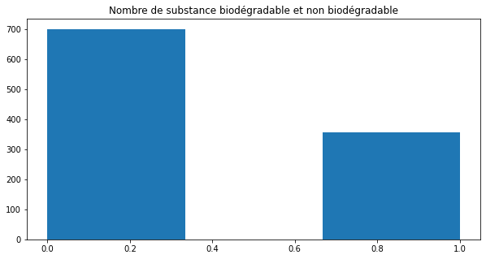

```
(355, 699)
```

```python
number_of_rd = np.sum(df["experimental_class"].values)
number_of_nrd = len(df) - number_of_rd
plt.figure(figsize=(10,5))
plt.hist(df["experimental_class"].values, bins = 3)
plt.title("Nombre de substance biodégradable et non biodégradable")
plt.show()
number_of_rd,number_of_nrd
```

Le nombre de composants biodégradables est de 355 et le nombre de composants non-biodégradables est de 699. Il y a donc un déséquilibre entre les classes, ce qui peut dans certains cas induire un biais en faveur de la classe majoritaire. Mais ici, le déséquilibre reste raisonnable (deux tiers / un tiers) et le jeu de données est tout de même d'une bonne taille (1054 individus), on peut donc laisser les données ainsi à ce stade.

### Matrice des corrélations

En prédiction, on souhaite éviter au maximum le phénomène de **multicolinéarité**, c'est à dire le fait qu'une variable explicative puisse être prédite efficacement à partir d'autres variables explicatives. L'existence de multicolinéarité peut rendre le modèle très sensible à de petites modifications du data set, ce qui rendrait le modèle moins pertinent. On va donc représenter ci-dessous la matrice des corrélations de nos 42 variables, pour voir s'il existe de fortes corrélations entre les variables explicatives. Pour deux variables explicatives fortement corrélées, on ne conserve que celle qui a la corrélation la plus élevée avec la variable cible.

```
(42.5, -0.5)
```

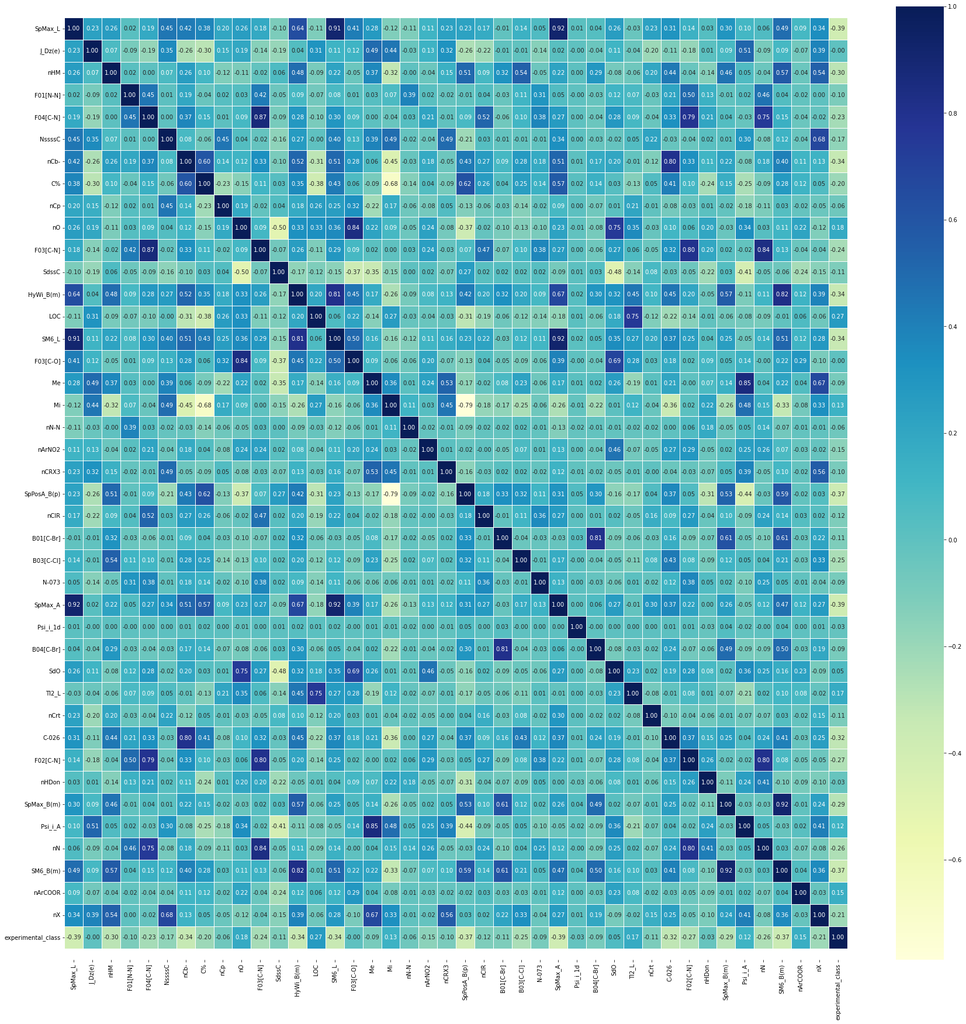

```python
corr_matrix = df.corr()
fig, ax = plt.subplots(figsize=(30, 30))
ax = sns.heatmap(corr_matrix,
                 annot=True,
                 linewidths=0.5,
                 fmt=".2f",
                 cmap="YlGnBu");
bottom, top = ax.get_ylim()
ax.set_ylim(bottom + 0.5, top - 0.5)
```

Au vu de cette matrice de corrélations, on décide de supprimer les variables "SM6_L","SpMax_A","SM6_B(m)" de notre base de données :

```python
corr_drop = ["SM6_L","SpMax_A","SM6_B(m)"]
corr_keep = list(set(df.columns)-set(corr_drop))
df = df[corr_keep]
df.head()
```

|  | N-073 | nN | experimental_class | C% | Psi_i_A | nArNO2 | B01[C-Br] | NssssC | nCb- | F03[C-N] | ... | LOC | F01[N-N] | nCrt | F02[C-N] | SdO | B03[C-Cl] | SpPosA_B(p) | nN-N | nCp | TI2_L |
| --- | --- | --- | --- | --- | --- | --- | --- | --- | --- | --- | --- | --- | --- | --- | --- | --- | --- | --- | --- | --- | --- |
| 0 | 0 | 0 | 1 | 30.80 | 1.97 | 0 | 0 | 0 | 0 | 0 | ... | 1.39 | 0 | 0 | 0 | 0.00 | 0 | 1.10 | 0 | 1 | 1.54 |
| 1 | 0 | 0 | 1 | 26.70 | 2.42 | 0 | 0 | 0 | 0 | 0 | ... | 2.58 | 0 | 0 | 0 | 0.00 | 0 | 1.09 | 0 | 2 | 4.89 |
| 2 | 0 | 0 | 1 | 20.00 | 5.00 | 0 | 0 | 0 | 0 | 0 | ... | 0.92 | 0 | 0 | 0 | 8.36 | 0 | 1.02 | 0 | 0 | 1.33 |
| 3 | 0 | 0 | 1 | 29.40 | 2.40 | 0 | 0 | 0 | 0 | 0 | ... | 2.75 | 0 | 0 | 0 | 10.35 | 0 | 1.14 | 0 | 2 | 5.59 |
| 4 | 0 | 0 | 1 | 28.60 | 2.56 | 0 | 0 | 0 | 0 | 0 | ... | 2.52 | 0 | 0 | 0 | 10.28 | 0 | 1.12 | 0 | 2 | 4.75 |

5 rows × 39 columns

À ce stade il nous reste donc 38 variables explicatives pour notre dataset

### Variables séparant le mieux les classes :

On va maintenant, à l'aide d'histogrammes, chercher quelles variables explicatives séparent le plus les classes de la variable cible. Pour cela il faut d'abord séparer nos variables en deux catégories : variables continues et catégorielles. On considère que si une variable contient moins de 10 valeurs unique, alors c'est une variable catégorielle.

```python
categorical_val = []
continous_val = []
for column in df.columns:
    if len(df[column].unique()) <= 10:
        categorical_val.append(column)
    else:
        continous_val.append(column)
```

Les variables catégorielles :

```python
categorical_val
```

```
['N-073',
 'nN',
 'experimental_class',
 'nArNO2',
 'B01[C-Br]',
 'B04[C-Br]',
 'nHDon',
 'nArCOOR',
 'nCRX3',
 'F01[N-N]',
 'nCrt',
 'B03[C-Cl]',
 'nN-N']
```

Les variables continues :

```python
continous_val
```

```
['C%',
 'Psi_i_A',
 'NssssC',
 'nCb-',
 'F03[C-N]',
 'SdssC',
 'Psi_i_1d',
 'SpMax_B(m)',
 'HyWi_B(m)',
 'nHM',
 'nCIR',
 'nO',
 'Mi',
 'Me',
 'nX',
 'F03[C-O]',
 'SpMax_L',
 'C-026',
 'F04[C-N]',
 'J_Dz(e)',
 'LOC',
 'F02[C-N]',
 'SdO',
 'SpPosA_B(p)',
 'nCp',
 'TI2_L']
```

On peut maintenant faire la représentation qu'on veut : on trace l'histogramme de chaque variable en superposant un histogramme (en bleu) pour les individus non-biodégradables et un autre (en rouge) pour les individus biodégradables :

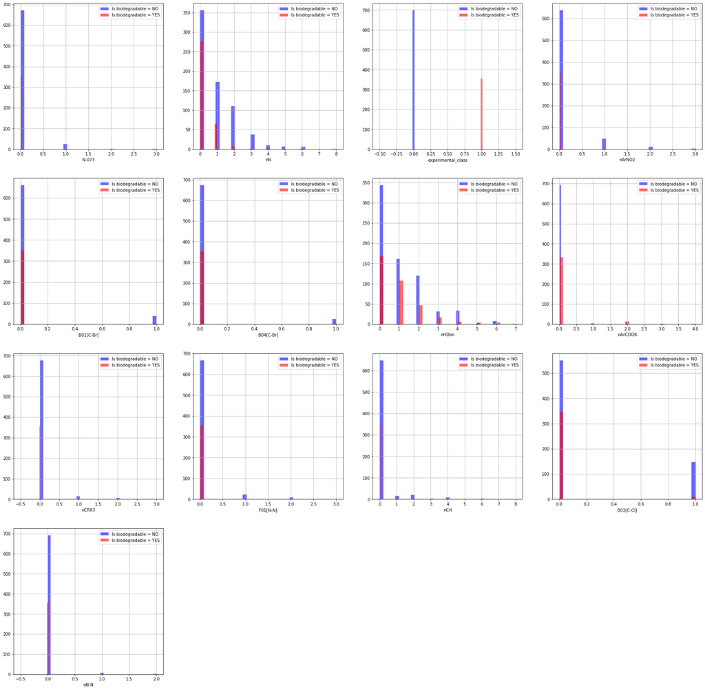

```python
plt.figure(figsize=(30, 30))

for i, column in enumerate(categorical_val, 1):
    plt.subplot(4, 4, i)
    df[df["experimental_class"] == 0][column].hist(bins=35, color='blue', label='Is biodegradable = NO', alpha=0.6)
    df[df["experimental_class"] == 1][column].hist(bins=35, color='red', label='Is biodegradable = YES', alpha=0.6)
    plt.legend()
    plt.xlabel(column)
```

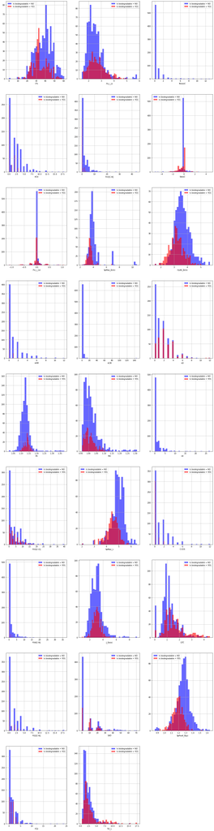

```python
plt.figure(figsize=(20, 100))

for i, column in enumerate(continous_val, 1):
    plt.subplot(11, 3, i)
    df[df["experimental_class"] == 0][column].hist(bins=35, color='blue', label='Is biodegradable = NO', alpha=0.6)
    df[df["experimental_class"] == 1][column].hist(bins=35, color='red', label='Is biodegradable = YES', alpha=0.6)
    plt.legend()
    plt.xlabel(column)
```

Au vu de ces figures, on conclut que les variables explicatives qui conduisent à une forte séparation des classes de la variable cible sont :

- SpPosA_B(p)
- HyWi_B(m)
- C%
- SpMax_B(m)
- SpMax_L

En effet c'est pour ces variables qu'on a des différences vraiment marquées entre les deux histogrammes, au sens où les histogrammes ne se superposent pas entièrement. On distingue bien graphiquement l'existence de deux classes. Pour mieux comprendre, si on regarde par exemple une variable comme J_Dz(e), on voit que l'histogramme rouge et l'histogramme bleu sont à peu près identique à différence d'échelle près (le rouge est plus petit du fait du déséquilibre entre les classes constaté plus haut).

## Data Processing

La partie précédente nous permet de constater qu'on à besoin de convertir les variables catégorielles. Pour cela on utilise la méthode get_dummies pour créer des variables factices. Elles agissent comme des indicateurs de la présence ou de l’absence d’une catégorie dans une variable catégorielle. Par convention 0 représente l’absence tandis que 1 représente la présence.

```python
# On supprime de la liste des variables catégorielles la variable cible
categorical_val.remove('experimental_class')
```

```python
dataset = pd.get_dummies(df, columns = categorical_val) # Permet d'encoder les variables catégorielles.
dataset.head()
```

|  | experimental_class | C% | Psi_i_A | NssssC | nCb- | F03[C-N] | SdssC | Psi_i_1d | SpMax_B(m) | HyWi_B(m) | ... | nCrt_3 | nCrt_4 | nCrt_5 | nCrt_6 | nCrt_8 | B03[C-Cl]_0 | B03[C-Cl]_1 | nN-N_0 | nN-N_1 | nN-N_2 |
| --- | --- | --- | --- | --- | --- | --- | --- | --- | --- | --- | --- | --- | --- | --- | --- | --- | --- | --- | --- | --- | --- |
| 0 | 1 | 30.80 | 1.97 | 0 | 0 | 0 | 0.00 | -0.20 | 3.31 | 2.46 | ... | 0 | 0 | 0 | 0 | 0 | 1 | 0 | 1 | 0 | 0 |
| 1 | 1 | 26.70 | 2.42 | 0 | 0 | 0 | 0.00 | -0.01 | 3.08 | 3.28 | ... | 0 | 0 | 0 | 0 | 0 | 1 | 0 | 1 | 0 | 0 |
| 2 | 1 | 20.00 | 5.00 | 0 | 0 | 0 | 0.00 | 1.07 | 3.05 | 2.10 | ... | 0 | 0 | 0 | 0 | 0 | 1 | 0 | 1 | 0 | 0 |
| 3 | 1 | 29.40 | 2.40 | 0 | 0 | 0 | -0.27 | -0.00 | 3.35 | 3.45 | ... | 0 | 0 | 0 | 0 | 0 | 1 | 0 | 1 | 0 | 0 |
| 4 | 1 | 28.60 | 2.56 | 0 | 0 | 0 | -0.28 | -0.01 | 3.35 | 3.31 | ... | 0 | 0 | 0 | 0 | 0 | 1 | 0 | 1 | 0 | 0 |

5 rows × 81 columns

Notre base de données est maintenant composées de 81 colonnes.

## Découpage des données

On découpe maintenant nos données en un jeu d'entraînement et un jeu de test. On définit experimental_class comme la variable cible et l'ensemble d'entraînement est composées de 80% des individus (et l'ensemble test des 20% restants).

```python
# Découpage du jeu de données en train test, test_size = 0.2 signifie
#que 20% de la base de données est utilisée comme données tests.

y = df.experimental_class # Variable cible
X = df.drop("experimental_class", axis = 1) # Variables explicatives
X_train, X_test, y_train , y_test = train_test_split(X,y ,random_state=29 , test_size = 0.2)
```

```python
X_train.shape, X_test.shape, y_train.shape , y_test.shape
```

```
((843, 38), (211, 38), (843,), (211,))
```

## Mise à l'échelle

On aimerait appliquer nos algorithmes de machine learning sur deux bases de données distinctes :

- Le dataset de base, simplement normalisé
- Le dataset auquel on applique une transformation B-spline

On effectue cette transformation B-spline car opérer une transformation sur les données peut permettre dans certains cas d'obtenir de meilleurs résultats, et il est donc intéressant de tester nos modèles sur les deux datasets et comparer l'efficacité entre les deux. Bien des transformations existent : polynômiale, exponentielle, transformation de Fourier, etc. Nous avons jeté notre dévolu sur les B-splines car la fonction permettant d'effectuer cette transformation est un ajout très récent de scikit-learn (elle date de la version 1.0, sortie fin septembre 2021).

### Base de données spline

Dans certains cas, opérer une transformation sur les données peut permettre d'obtenir de meilleurs résultats de prédiction. Il existe bien des transformations possibles : polynômiale, exponentielle, de Fourier, etc. Ici, nous allons à l'aide de la fonction SplineTransformer de scikit learn, générer des **B-splines** univariés pour nos variables.

Définissons d'abord les fonctions B-spline : on fixe au préalable $q+1$ nœuds $k_0 < k_1 < \dots < k_q$ et un degré $p$ pour les splines. Les fonctions B-splines de degré $p$ sont définies par récurrence sur le degré inférieur : pour $j = 1,\dots,q$ et $t\in\mathbb{R}$, on pose :

- $b_{j,0}(t) = 1$ si $k_{j-1} < t < k_j$ et $0$ sinon
- $b_{j,p}(t) = \displaystyle \frac{t-k_{j-1}}{k_{j-1+p} - k_{j-1}} b_{j-1,p-1}(t) + \displaystyle \frac{k_{j+p} - t}{k_{j+p} - k_{j}} b_{j,p-1}(t) $

Lorsqu'on applique la fonction SplineTransformer avec en paramètres un nombre de nœuds n_knots et un degré degree, on crée un nouvelle matrice de variables. Si on a d variables au départ, notre nouvelle matrice sera formée de d*(n_knots + degree - 1) variables, correspondant à (n_knots + degree - 1) fonctions B-spline de degré degree de chaque variable de la base de départ.

```python
spline = SplineTransformer(degree=12, n_knots=3)
spline.fit_transform(X_train)
spline.get_feature_names_out()
X_train_spline = (pd.DataFrame(spline.transform(X_train),columns = spline.get_feature_names_out()))
X_test_spline = (pd.DataFrame(spline.transform(X_test),columns = spline.get_feature_names_out()))
```

#### Normalisation des données :

Les variables continues ont des échelles différentes. Pour améliorer les performances du modèle, on normalise les données (c'est à dire qu'on les centre et on les réduit), afin qu'elles aient une échelle commune.

```python
spline_scaler = StandardScaler()
spline_scaler.fit(X_train_spline)
X_train_spline_n = pd.DataFrame(spline_scaler.transform(X_train_spline),columns = X_train_spline.columns)
X_test_spline_n = pd.DataFrame(spline_scaler.transform(X_test_spline),columns = X_test_spline.columns)
```

```python
X_train_spline_n.shape, X_test_spline_n.shape
```

```
((843, 532), (211, 532))
```

### Base de données normalisée

Ici on va seulement normaliser les données, sans transformation sophistiquée :

```python
spline_scaler = StandardScaler()
spline_scaler.fit(X_train)
X_train_n = pd.DataFrame(spline_scaler.transform(X_train),columns = X_train.columns)
X_test_n = pd.DataFrame(spline_scaler.transform(X_test),columns = X_test.columns)
```

## Sélection des variables

Dans cette partie, nous allons, à l'aide de modèles de machine learning, classer nos variables par leur pouvoir prédictif, et ne conserver que celles qui ont le plus fort impact sur la variable cible.

On applique successivement deux méthodes pour la sélection de variables :

- D'abord une régression logistique avec pénalité lasso : on supprimera les variables ayant un poids de 0 avec la pénalité lasso
- Ensuite une random forest à l'issue de laquelle on ne conservera que les 15 meilleures variables

Nous allons expliquer plus bas en quoi consistent ces deux modèles, qui seront d'ailleurs également utilisés par la suite dans la partie modélisation :

### Première étape de sélection : régression logistique avec pénalité lasso

Dans un modèle de **régression logistique** où $ Y $ est la variable de Bernoulli cible (ici $Y$ vaut 1 si le composant est biodégradable, 0 sinon) et $ X \in \mathbb{R}^d $ la variable explicative (on peut considérer nos $d$ variables explicatives réelles comme une seule variable de dimension $d$), on fait l'hypothèse suivante : pour $ x \in \mathbb{R}^d $ ,

$ \eta (x) = \mathbb{P}(Y = 1 | X = x) = \sigma(b_0 + b_1x_1 + \dots + b_dx_d) = \displaystyle \frac{1}{1 + \exp{(-(b_0 + b_1x_1 + \dots + b_dx_d))}} $

Où :

$\sigma$ est appelée la fonction sigmoïde exponentielle. C'est une fonction strictement croissante sur $\mathbb{R}$, qui tend vers $0$ en $-\infty$ et vers $1$ en $+\infty$ (donc on a bien une probabilité entre 0 et 1)

$ \eta $ est la fonction d'intérêt, i.e. la fonction décrivant la loi conditionnelle de $Y$ sachant $X = x$ (conditionnellement à $ X = x $, $Y$ est une loi de Bernoulli de paramètre $p = \eta(x)$ )

Les $ b_1,...,b_n $ sont les poids du modèle (à estimer en pratique pour que le modèle colle le mieux aux données) et $ b_0 $ est l'ordonnée à l'origine ou intercept (à estimer également).

Le modèle est appelé régression logistique car l'image de $\eta$ par la fonction logistique $ logit(s) = ln(s) - ln(1-s)$ (bijection réciproque de la sigmoïde) est linéaire.

Lorsqu'on applique le modèle de régression logistique à nos données, les poids $b_j$ que nous sort le modèle indiquent quelles variables explicatives ont le plus d'influence sur la valeur de la variable cible. Les poids peuvent être négatifs, c'est leur valeur absolue qui indiquera l'importance de la variable correspondante.

Ici, pour effectuer la sélection des variables, on applique une régression avec **pénalité lasso**, c'est à dire qu'on impose la contrainte suivante sur la norme $\ell_{1}$ du vecteur des poids $b_j$ :

$ \displaystyle \sum_{j=1}^{d} |b_j| \le \tau $

où $\tau$ est un paramètre qui contrôle le niveau de régularisation des poids estimés.

Pour respecter cette contrainte, le modèle va contracter la valeur des coefficients $b_j$ et en annuler certains (les mettre à 0). Cela différencie la régression lasso de la régression ridge, qui contracte les coefficients mais ne peut pas les annuler (car elle met une contrainte sur la norme $\ell_{2}$, la moyenne quadratique des coefficients ; c'est la différence entre les deux normes qui permet à la régression lasso de mettre certains coefficients à 0). La régression lasso permet ainsi d'exclure du modèle prédictif des variables peu intéressantes, et c'est ce que nous allons faire ici.

```python
lg = LogisticRegression(solver = "liblinear", penalty = "l1", random_state=22, max_iter = 1000)
lg.fit(X_train_n,y_train)
lg_pred = lg.predict(X_test_n)
```

Il semble que plusieurs variables aient un coefficient égale à zéro. On supprime donc ces variables du jeu de données :

```python
pd.options.display.max_rows = 20
feat_imp_df = pd.DataFrame(data = {"Nom des variables": X_train_n.columns,"Importance des variables":lg.coef_[0]})
feat_imp_df = feat_imp_df.sort_values("Importance des variables",ascending=False)[:]

# Applique la fonction valeur absolue à la colonne des coefficients
feat_imp_df["Importance des variables"] = feat_imp_df["Importance des variables"].apply(lambda x: abs(x)).sort_values(ascending = False)

# Sélectionne les variables avec un coefficient nul
indexNames = feat_imp_df[ feat_imp_df["Importance des variables"] == 0].index

feat_imp_df.drop(indexNames , inplace=True) # Supprime les variables avec un coefficient nul
feat_imp_df.sort_values(ascending = False,by = "Importance des variables")
```

|  | Nom des variables | Importance des variables |
| --- | --- | --- |
| 7 | nCb- | 1.88 |
| 6 | NssssC | 1.34 |
| 12 | HyWi_B(m) | 1.11 |
| 2 | C% | 1.05 |
| 13 | nHM | 0.98 |
| ... | ... | ... |
| 15 | B04[C-Br] | 0.20 |
| 8 | F03[C-N] | 0.18 |
| 10 | Psi_i_1d | 0.11 |
| 19 | Me | 0.01 |
| 24 | SpMax_L | 0.01 |

32 rows × 2 columns

```python
X_train_1 = X_train_n[list(feat_imp_df["Nom des variables"])]
X_test_1 = X_test_n[list(feat_imp_df["Nom des variables"])]
```

### Seconde étape de sélection : random forest

Le modèle de **random forest** consiste à traiter le problème en combinant les résultats de plusieurs modèles simples dont chacun aura une vision parcellaire du problème (plutôt qu'un seul gros modèle complexe qui prend tout en compte). Ces modèles simples sont ce qu'on appelle des **arbres de décision**.

Un arbre de décision, lorsqu'on lui soumet une observation, va interroger successivement les variables explicatives en posant à chaque fois une question dont la réponse est oui ou non (pour les variables catégorielles cela sera l'appartenance à un groupe de catégories ou l'autre, pour les variables continues on regardera si la valeur est inférieure ou supérieure à un certain seuil).  
Selon la réponse à la question, l'arbre peut prendre immédiatement la décision finale sur la valeur de la variable catégorielle cible (ici 1 ou 0, biodégradable ou non) pour la nouvelle observation, soit poser une nouvelle question. On a ainsi une arborscence de questions avec des branches (enchaînements de questions) plus ou moins longues se terminant par des feuilles (décisions sur la catégorie 0 ou 1).  
L'apprentissage d'un arbre décisionnel se passe comme suit : grâce au set d'entraînement (où la réponse pour la variable cible est connue), l'arbre va identifier quelles sont les questions dont la réponse apporte le plus d'information permettant de tendre vers la décision finale. L'arbre va donc ranger les questions par odre de pertinence, et les poser dans cet ordre. Dit autrement, l'arbre va trouver quelles variables explicatives ont le plus de pouvoir prédictif. On peut donc utiliser le modèle random forest pour faire de la sélection de variables sur nos données avant de se lancer dans la prédiction/classification.  
Prenons un exemple concret plus simple que nos composants chimiques : supposons que l'on veuille déterminer si un champignon est comestible ou non, sachant qu'on dispose d'une base de données de champigons dont on sait pour chacun s'il l'est ou non. La méthode de l'arbre décisionnel va regarder d'abord la couleur du champignon car il a identifié dans la base d'entraînement que certaines couleurs garantissaient de ne pas être comestible. Si la réponse est une couleur qui ne rend pas obligatoirement non-comestible, l'arbre interrogera ensuite la présence ou non de tâches car il a vu que la présence de tâches combinée à certaines couleurs garantissait la comestibilité, etc.  
Préalablement à l'apprentissage, il faut fixer un critère de séparation : l'arbre construit en effet des sous-populations dans le set d'entraînement par séparations successives des feuilles. Ici nous utiliserons le critère d'entropie. Ce critère se base sur la mesure du désordre qui règne dans la population étudiée. Par exemple, un test qui divise une classe en deux classes non finales de même taille a une entropie très élevée, car il rest encore beaucoup de tests à faire. Au contraire, si tous les objets appartiennent finalement à la même classe, il n’y a aucun désordre : on est arrivés à une feuille.

Maintenant que nous avons vu comment fonctionnait un arbre, il faut expliquer le fonctionnement de la random forest en elle-même. Il y a 2 étapes fondamentales :

- Le **tree bagging** : sur la base d'entraînement, on génère aléatoirement $n$ sous-ensembles d'individus, et on entraîne un arbre de décision sur chacun de ces sous-ensembles. Bien sûr deux sous-ensembles peuvent avoir des individus en commun, le tirage se fait avec remise à chaque changement
- Le **feature sampling** : lors de l'apprentissage, on entraîne les arbres sur toutes les variables. Mais avant de soumettre un nouvelle observation aux arbres, on procède pour chaque arbre à un tirage aléatoire des variables qui seront testées, c'est à dire que l'arbre ne posera pas toutes les questions. Typiquement, pour un problème à $d$ variables, on limitera à $\sqrt{d}$ variables par arbre (toujours avec remise lorsqu'on change d'arbre). Ce processus permet de diminuer la corrélation entre les arbres.

Ces étapes de tree bagging et de feature sampling sont essentielles pour éviter tout problème de **surapprentissage**. De base, le phénomène de surapprentissage est inhérent aux arbres de décision, car leur structure fait qu'ils collent extrêmement bien aux données. C'est pourquoi on procède à ce fractionnement en entraînant les arbres sur des échantillons parcellaires et différents et en restreignant aléatoirement le nombre de questions posées.

Le modèle est maintenant prêt à faire de la classification. On soumet la nouvelle observation à chacun des arbres, et on prend la décision finale au vote majoritaire. En l'occurrence, si une majorité d'arbres classe le composant comme biodégradable, on le considère comme biodégradable.

Dans cette section nous allons seulement nous servir de la random forest pour sélectionner les variables les plus intéressantes. Nous utiliserons le modèle dans la partie Modélisation pour faire de la classification.

```python
rf = RandomForestClassifier(n_estimators=1000,max_features = 31,criterion = "entropy",n_jobs=-1,bootstrap=True,
                           verbose=0,random_state=1)
rf.fit(X_train_1,y_train)
```

```
RandomForestClassifier(criterion='entropy', max_features=31, n_estimators=1000,
                       n_jobs=-1, random_state=1)
```

```python
rf_pred = rf.predict(X_test_1)
```

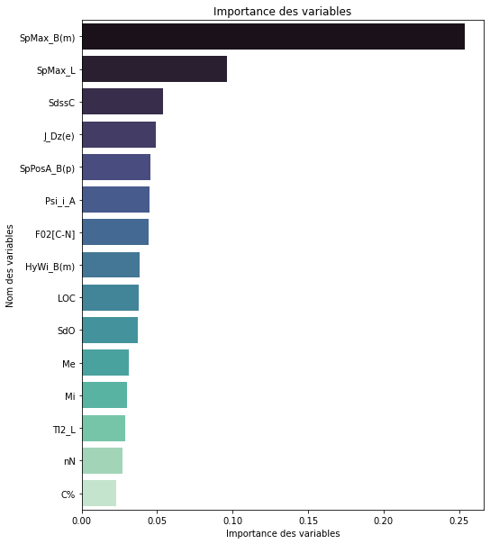

```python
feat_imp_df = pd.DataFrame(data = {"Nom des variables": X_train_1.columns,
"Importance des variables":rf.feature_importances_})

feat_imp_df = feat_imp_df.sort_values("Importance des variables",ascending=False)[:]

fig,ax = plt.subplots(figsize=(8,10))
ax = sns.barplot(x = "Importance des variables",y = "Nom des variables",
data=feat_imp_df.sort_values("Importance des variables",ascending=False)[:15],palette="mako")
plt.title('Importance des variables')
```

Sur la base des résultats de la random forest, on décide de conserver pour la suite les **15** variables les plus importantes.

On crée la base de données restreinte aux 15 variables les plus importantes :

```python
X_train_final = X_train_n[list(feat_imp_df["Nom des variables"])[:15]]
```

```python
X_test_final  = X_test_n[list(feat_imp_df["Nom des variables"])[:15]]
```

```python
X_train_final.shape, X_test_final.shape, y_train.shape , y_test.shape
```

```
((843, 15), (211, 15), (843,), (211,))
```

#### Sélection de variables pour la base de données splines

On applique le même procédé pour la base de données splines :

```python
lg_spline = LogisticRegression(solver = "liblinear", penalty = "l1", random_state=22, max_iter = 1000)
lg_spline.fit(X_train_spline_n,y_train)
lg_spline_pred = lg_spline.predict(X_test_spline_n)
```

```python
pd.options.display.max_rows = 20
feat_imp_df = pd.DataFrame(data = {"Nom des variables": X_train_spline_n.columns,
"Importance des variables":lg_spline.coef_[0]})

feat_imp_df = feat_imp_df.sort_values("Importance des variables",ascending=False)[:]

# Applique la fonction valeur absolue à la colonne des coefficients
feat_imp_df["Importance des variables"] = feat_imp_df["Importance des variables"].apply(lambda x: abs(x)).sort_values(ascending = False)

# Sélectionne les variables avec un coefficient nulle
indexNames = feat_imp_df[ feat_imp_df["Importance des variables"] == 0].index

feat_imp_df.drop(indexNames , inplace=True) # Supprime les variables avec un coefficient nulle
feat_imp_df
```

|  | Nom des variables | Importance des variables |
| --- | --- | --- |
| 50 | Psi_i_A_sp_8 | 1.94 |
| 103 | nCb-_sp_5 | 1.83 |
| 482 | SpPosA_B(p)_sp_6 | 1.64 |
| 348 | SpMax_L_sp_12 | 1.32 |
| 84 | NssssC_sp_0 | 1.03 |
| ... | ... | ... |
| 252 | nHDon_sp_0 | 0.94 |
| 441 | F02[C-N]_sp_7 | 1.10 |
| 175 | HyWi_B(m)_sp_7 | 1.24 |
| 228 | nO_sp_4 | 1.30 |
| 246 | Mi_sp_8 | 2.87 |

111 rows × 2 columns

```python
X_train_spline_1 = X_train_spline_n[list(feat_imp_df["Nom des variables"])]
X_test_spline_1 = X_test_spline_n[list(feat_imp_df["Nom des variables"])]
```

```python
rf = RandomForestClassifier(n_estimators=1000,max_features = 31,criterion = "entropy",n_jobs=-1,
bootstrap=True,verbose=0,random_state=1)

rf.fit(X_train_spline_1,y_train)
rf_pred = rf.predict(X_test_spline_1)
```

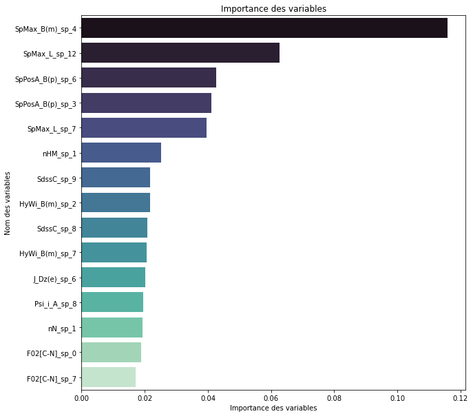

```python
feat_imp_df = pd.DataFrame(data = {"Nom des variables": X_train_spline_1.columns,
        "Importance des variables":rf.feature_importances_})

feat_imp_df = feat_imp_df.sort_values("Importance des variables",ascending=False)[:]

fig,ax = plt.subplots(figsize=(10,10))
ax = sns.barplot(x = "Importance des variables",y = "Nom des variables",
 data=feat_imp_df.sort_values("Importance des variables",ascending=False)[:15],palette="mako")
plt.title('Importance des variables')
```

```python
X_train_spline_final = X_train_spline_1[list(feat_imp_df["Nom des variables"])[:15]]
```

```python
X_test__spline_final  = X_test_spline_1[list(feat_imp_df["Nom des variables"])[:15]]
```

## Modélisation

Dans cette partie on va tester différents modèles. On crée un dictionnaire pour stocker nos modèles afin de pouvoir les comparer plus tard :

```python
dict_models_pred={}
```

### Régression Logistique

Dans un premier temps avec la base de données classiques. On effectue une régression logistique avec cette fois-ci une pénalisation $\ell_{2}$. On affiche les scores du modèle et sa matrice de confusion. On effectue plusieurs tests pour choisir la constante de pénalisation C.

```
Accuracy: 0.85
Précision: 0.83
Sensitivité: 0.73
F1: 0.78
```

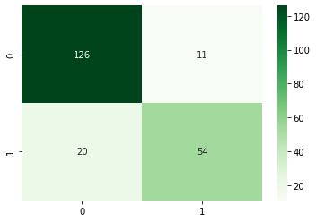

```python
logRegB = LogisticRegression(penalty = "l2", C = 0.8)#On crée notre régression logistique
logRegB.fit(X_train_final,y_train)#On la fit à nos données
logRegB_pred = logRegB.predict(X_test_final)# On prédit nos données

dict_models_pred['logRegB']=logRegB_pred #On ajoute les résultats dans notre dictionnaire

model_score(y_test,logRegB_pred) #Score
matrice_conf(y_test,logRegB_pred)# Matrice de confusion
```

La **matrice de confusion** est une manière de visualiser la qualité du modèle. Les lignes correspondent aux classes réelles et les colonnes aux classes estimées. Le nombre en ligne, $i$, colonne $j$, représente le nombre d'individus du jeu de test appartenant à la classe $i$ qui ont été estimés par le modèle comme appartenant à la classe $j$.

On trouvera donc sur la diagonale le nombre d'individus correctement classés pour chaque classe, et ailleurs toutes les erreurs. Par exemple en ligne 0, colonne 1, on trouvera le nombre de composants non-biodégradables classés à tort comme biodégradables (faux positifs), ici 11.

Même chose avec la base de données splines :

```
Accuracy: 0.86
Précision: 0.82
Sensitivité: 0.76
F1: 0.79
```

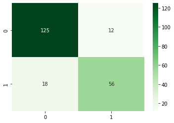

```python
logRegS = LogisticRegression(penalty = "l2", C = 0.7)#On crée notre régression logistique
logRegS.fit(X_train_spline_final,y_train)#On la fit à nos données
logRegS_pred = logRegS.predict(X_test__spline_final)# On prédit nos données

dict_models_pred['logRegS']=logRegS_pred #On ajoute les résultats dans notre dictionnaire

model_score(y_test,logRegS_pred)#Score
matrice_conf(y_test,logRegS_pred)# Matrice de confusion
```

### RandomForest

```
Accuracy: 0.85
Précision: 0.78
Sensitivité: 0.81
F1: 0.79
```

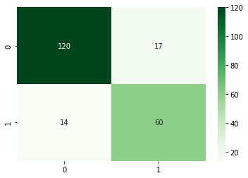

```python
rfB = RandomForestClassifier(n_estimators=200)#On crée notre RandomForest
rfB.fit(X_train_spline_final,y_train)#On la fit à nos données
rfB_pred =rfB.predict(X_test__spline_final)# On prédit nos données

dict_models_pred['rfB']=rfB_pred  #On ajoute les résultats dans notre dictionnaire

model_score(y_test,rfB_pred) #Score
matrice_conf(y_test,rfB_pred) #Matrice de confusion
```

```
Accuracy: 0.85
Précision: 0.78
Sensitivité: 0.78
F1: 0.78
```

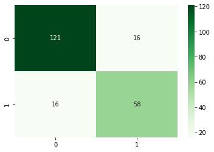

```python
rfS = RandomForestClassifier(n_estimators=200)#On crée notre RandomForest
rfS.fit(X_train_final,y_train)#On la fit à nos données
rfS_pred =rfS.predict(X_test_final)# On prédit nos données

dict_models_pred['rfS']=rfS_pred  #On ajoute les résultats dans notre dictionnaire

model_score(y_test,rfS_pred) #Score
matrice_conf(y_test,rfS_pred) #Matrice de confusion
```

### K plus proches voisins

Le modèle des **K plus proches voisins** (K nearest neighbours) consiste à prédire la catégorie d'un nouvel individu dans la variable cible (ici 1 ou 0, biodégradable ou non) en fonction de la catégorie majoritaire parmi les K individus qui sont les plus proches du nouveau dans le set d'entraînement :

On fixe un entier $K$, et on répertorie dans le set d'entraînement les $K$ individus qui sont les plus proches du nouvel individu, au sens de la distance euclidienne de $ \mathbb{R}^d $ (d le nombre de variables explicatives). Si parmi ces $K$ individus la catégorie majoritaire dans la variable cible est 1, on assigne à notre nouvel individu la valeur 1 pour la variable cible, sinon on lui assigne 0.

À noter que ce modèle est à utiliser avec parcimonie lorsqu'on a des variables catégorielles dans les données, car des variables discrètes induisent une topologie impropre et peuvent donc fausser les prédictions. C'est surtout vrai lorsque ces variables sont des nombres choisis arbitrairement pour coder une caractéristique (typiquement, dans notre cas, si experimental_class était une variable explicative) et ne correspondent à aucune donnée numérique réelle.

Le choix de $K$ est crucial pour ce modèle. Naturellement $K$ sera toujours pris impair pour qu'il n'y ait pas d'ex-æquo. Afin de déterminer le meilleur $K$, on va, pour chaque valeur $k$ entre 1 et 40, tester le modèle des $k$ plus proches voisins et calculer son taux d'erreur (proportion de mauvais classements sur la base de test). On choisira le $K$ qui donne le taux d'erreur le plus faible :

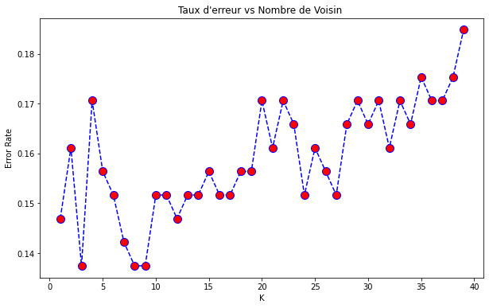

```python
from sklearn.neighbors import KNeighborsClassifier

erreur=[]
for i in range(1,40):
    knn = KNeighborsClassifier(n_neighbors=i)
    knn.fit(X_train_final,y_train)
    pred_i = knn.predict(X_test_final)
    erreur.append(np.mean(pred_i != y_test))

plt.figure(figsize=(10,6))
plt.plot(range(1,40),erreur,color="blue",linestyle="dashed", marker="o",markerfacecolor="red", markersize=10)
plt.title("Taux d'erreur vs Nombre de Voisin ")
plt.xlabel("K")
plt.ylabel("Error Rate")
```

On choisit de prendre 3 voisins d'après le graphique. À noter qu'avec 9 voisins l'erreur est aussi basse qu'avec 3.

```
Accuracy: 0.86
Précision: 0.79
Sensitivité: 0.82
F1: 0.81
```

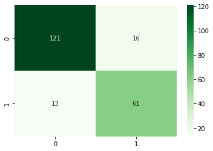

```python
knnB = KNeighborsClassifier(n_neighbors=3)#On crée notre KNN
knnB.fit(X_train_final,y_train) #On la fit à nos données
knnB_pred = knnB .predict(X_test_final)# On prédit nos données

dict_models_pred['knnB']=knnB_pred  #On ajoute les résultats dans notre dictionnaire

model_score(y_test,knnB_pred) #Score
matrice_conf(y_test,knnB_pred) #Matrice de confusion
```

Même chose pour la base de données splines.

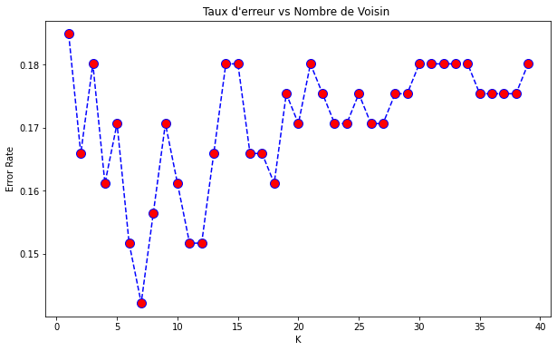

```python
erreur=[]

for i in range(1,40):
    knn = KNeighborsClassifier(n_neighbors=i)
    knn.fit(X_train_spline_final,y_train)
    pred_i = knn.predict(X_test__spline_final)
    erreur.append(np.mean(pred_i != y_test))

plt.figure(figsize=(10,6))
plt.plot(range(1,40),erreur,color="blue",linestyle="dashed", marker="o",markerfacecolor="red", markersize=10)
plt.title("Taux d'erreur vs Nombre de Voisin ")
plt.xlabel("K")
plt.ylabel("Error Rate")
```

D'après le graphique on décide de prendre $k=7$ cette fois.

```
Accuracy: 0.86
Précision: 0.81
Sensitivité: 0.77
F1: 0.79
```

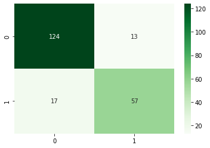

```python
knnS = KNeighborsClassifier(n_neighbors=7)#On crée notre KNN
knnS.fit(X_train_spline_final,y_train) #On la fit à nos données
knnS_pred = knnS.predict(X_test__spline_final)# On prédit nos données

dict_models_pred['knnS']=knnS_pred  #On ajoute les résultats dans notre dictionnaire

model_score(y_test,knnS_pred) #Score
matrice_conf(y_test,knnS_pred) #Matrice de confusion
```

### SVM

Une **machine à vecteur de support linéaire** consiste à trouver un hyperplan (sous-espace de dimension $d-1$ si $d$ est la dimension de l'espace de départ) séparateur entre les points du dataset.

Pour $i = 1,\dots,N$ avec $N$ le nombre d'individus, soit $x_i \in \mathbb{R}^d $ nos points et $y_i$ les étiquettes associées (biodégradable ou non en l'occurrence). Dans la théorie mathématique du SVM, on prend 1 ou -1 comme valeurs pour les $y_i$ (le modèle implémenté s'adaptera tout seul en considérant les 0 comme des -1, il n'y a pas de modification à faire sur nos données).

Le but est de trouver $H = \{x \in \mathbb{R}^d : w^Tx + b = 0 \} $

Où $b \in \mathbb{R}$ est le déplacemet par rapport à l'origine et $w \in \mathbb{R}^d$ non-nul est le vecteur orthogonal à $H$. $H$ doit séparer le dataset en deux régions, une où les $y_i$ valent 1 et une où les $y_i$ valent -1.

On voudra choisir $H$ de façon à maximiser la marge, définie par $ \displaystyle \min_{i=1,\dots,N} d(x_i,H)$

Où $d(x_i,H)$ est la distance entre le points $x_i$ et $H$. Autrement dit on veut $H$ le plus éloigné possible des points (naturellement il ne doit passer par aucun point).

Naturellement les données ne sont en général pas **linéairement séparables**, c'est à dire qu'il n'est généralement pas possible de trouver un $H$ qui sépare parfaitement le dataset selon les deux catégories.

Afin de palier à ce problème, on introduit des **variables d'écart** $s_i$ (nombres positifs). Ces variables vont permettre d'autoriser quelques points à être du mauvais côté de $H$.

On cherchera alors à résoudre le problème d'optimisation suivant :

$ \displaystyle \min_{w \in \mathbb{R}^d, b\in \mathbb{R}, s \in \mathbb{R}^N} \displaystyle \frac{\Vert w \Vert^2_2}{2} + C \displaystyle \sum_{i=1}^{N} s_i $

Avec les contraintes : pour $i = 1,\dots,N$, $ y_i(w^Tx_i + b) \geq 1 - s_i$ et $s_i \geq 0$

(avec $C>0$ une constante)

On peut montrer mathématiquement (en utilisant le lagrangien, les conditions KKT et l'étude de la dualité) que ce problème admet une unique solution.

Le modèle SVM implémenté va donc déterminer cette unique solution par des algorithmes d'optimisation, ce qui nous donnera l'hyperplan $H$. Une nouvelle observation sera classée biodégradable ou non selon de quel côté de $H$ elle se trouve.

```
Accuracy: 0.83
Précision: 0.77
Sensitivité: 0.74
F1: 0.76
```

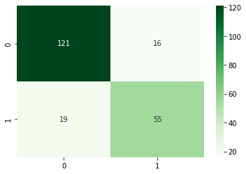

```python
from sklearn.svm import SVC

svmB = SVC(kernel = 'linear')#On crée notre SVM
svmB.fit(X_train_final,y_train) #On la fit à nos données
svmB_pred =svmB.predict(X_test_final)# On prédit nos données

dict_models_pred['svmB']=svmB_pred  #On ajoute les résultats dans notre dictionnaire

model_score(y_test,svmB_pred) #Score
matrice_conf(y_test,svmB_pred) #Matrice de confusion
```

Même chose pour la base de données splines.

```
Accuracy: 0.86
Précision: 0.82
Sensitivité: 0.76
F1: 0.79
```

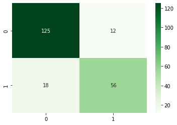

```python
svmS = SVC(kernel = 'linear')#On crée notre SVM
svmS.fit(X_train_spline_final,y_train) #On la fit à nos données
svmS_pred =svmS.predict(X_test__spline_final)# On prédit nos données

dict_models_pred['svmS']=svmS_pred  #On ajoute les résultats dans notre dictionnaire

model_score(y_test,svmS_pred) #Score
matrice_conf(y_test,svmS_pred) #Matrice de confusion
```

### AdaBoost

L'**adaptative boosting**, aussi appelé adaboost, est comme son nom l'indique une méthode de **boosting**.

Le boosting consiste à combiner par itérations successives des classeurs dits faibles pour obtenir un classifieur final (dit fort). Les classifieurs faibles sont des classifieurs capables de reconnaître deux classes au moins aussi bien que ne le ferait une sélection au hasard (c'est à dire la sélection qui consisterait dans notre cas présent à prédire un composant comme biodégradable selon une loi de Bernoulli dont le paramètre serait la proportion de biodégradables dans le jeu d'entraînement). Il est possible de démontrer que tant que les classifieurs faibles sont meilleurs qu'une prédiction aléatoire, la combinaison va converger vers un classifieur fort.

L'adaboost, forme la plus répandue de boosting, fait référence à une technique particulière pour combiner les classifieurs faibles : pour obtenir la sortie finale prédisant la valeur de la variable cible, on prend la somme pondérée des prédictions effectuées par les classifieurs faibles. Le poids assigné à un classifieur donné dans la pondération sera d'autant plus important que ce classifieur prédit bien : mieux il classe, plus il aura de poids.

L'apprentissage du classifieur fort se passe comme suit : à chaque étape $t$ ($t$ allant de $1$ à $T$ où $T$ est le nombre de classifieurs faibles) de l'entraînement, on sélectionne un classifieur faible, et on l'ajoute à la somme (on construit le classifieur fort petit à petit) en lui assignant un certain coefficient multiplicatif $\alpha_t$. Ce coefficient est choisi de manière à minimiser l'erreur de classification suivante :

$E_t = \displaystyle \sum_{i} E(F_{t-1}(x_i) + \alpha_th(x_i)) $

Où :

- les $x_i$ sont les observations
- $F_{t-1}$ est le classifieur fort provisoire à l'étape $t-1$
- $h$ est la fonction de prévision pour le classifieur en cours de sélection. Dans notre cas elle détermine si une observation $x$ va être classée comme biodégradable ou non.
- $E$ est une fonction d'erreur qui s'applique à un classifieur $F$

Ainsi on construit étape par étape notre classifieur final $F_T$. En ce sens l'adaboost est bien comme son nom l'indique adaptative : lorsqu'on ajoute un classifieur faible, on l'adapte en fonction de ce qui a été fait dans les étapes précédentes. De cette manière on fait en sorte qu'un classifieur soit performant là où les précédents l'étaient moins, ce qui aide à éviter le surapprentissage.

Ici on crée un modèle d'adaboost avec la fonction AdaBoostClassifier, qui utilise des arbres de décision comme classifieurs. Après avoir testé ("à la main") différentes valeurs, on choisit de prendre 85 classifieurs faibles :

```
Accuracy: 0.85
Précision: 0.74
Sensitivité: 0.86
F1: 0.8
```

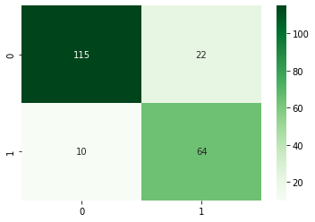

```python
from sklearn.ensemble import AdaBoostClassifier

adaB = AdaBoostClassifier(n_estimators=85) #On crée notre AdaBoost
adaB.fit(X_train_final,y_train) #On la fit à nos données
adaB_pred =adaB.predict(X_test_final)# On prédit nos données

dict_models_pred['adaB']=adaB_pred  #On ajoute les résultats dans notre dictionnaire

model_score(y_test,adaB_pred) #Score
matrice_conf(y_test,adaB_pred) #Matrice de confusion
```

Même chose pour la base de données splines.

```
Accuracy: 0.85
Précision: 0.75
Sensitivité: 0.85
F1: 0.8
```

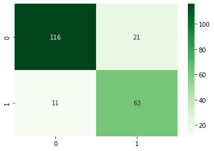

```python
adaS = AdaBoostClassifier(n_estimators=85) #On crée notre AdaBoost
adaS.fit(X_train_spline_final,y_train) #On la fit à nos données
adaS_pred =adaS.predict(X_test__spline_final)# On prédit nos données

dict_models_pred['adaS']=adaS_pred  #On ajoute les résultats dans notre dictionnaire

model_score(y_test,adaS_pred) #Score
matrice_conf(y_test,adaS_pred) #Matrice de confusion
```

### Perceptron Multicouche

Un réseau de neurones est un graphe orienté pondéré dont les nœuds sont appelés neurones artificiels et les arêtes (liens entre les nœuds) des synapses (l'idée originale du concept était d'essayer de reproduire le comportement des neurones du cerveau humain).

À chaque neurone est attribué un état interne appelé l'activation $ a \in \mathbb{R} $ et à chaque synapse est attribuée un poids $w \in \mathbb{R} $. Les poids sont répertoriés dans la matrice des poids $W$.

Le comportement d'un neurone artificiel est le suivant : un neurone $i$ reçoit des entrées $x_j$ (nombres réels) auxquels il applique une fonction d'entrée $h$, qui est le plus souvent la combinaison linéaire des entrées pondérée par les poids $w^i_j$ des synapses reliant les neurones d'entrée au neurone $i$. :

$h(x_1, \dots, x_d) = \displaystyle \sum_{j=1}^{d} w_{i,j}x_j$

Une fois cette transformation faite, le neurone $i$ applique au nombre obtenue une fonction d'activation $f$ (à valeurs dans $\mathbb{R}$), ce qui permet d'obtenir en sortie l'activation du neurone $i$.

Construire un réseau de neurones, c'est donc se fixer :

- Une architecture (nombre de neurones, connexions entre les neurones)
- Une matrice $W$ des poids des connexions entre les neurones (où l'absence de connexion se traduira par un poids égal à 0)
- Une fonction d'activation $f$

$f$ est généralement la même pour tous les neurones, ou du moins tous les neurones d'une même couche. Parmi les choix les plus fréquents pour $f$, on trouvera entre autres la sigmoïde exponentielle (vue plus haut), la tangente hyperbolique (ou sigmoïde tangentielle), ou bien encore la fonction partie positive (appelée alors unité de rectification linéaire ou ReLU en anglais).

Lorsque plusieurs couches de neurones se succèdent, un neurone prend en entrée les activations des neurones de la couche précédente et fournit son activation comme entrée pour les neurones de la couche suivante. C'est le cas par exemple d'un grand classique des réseaux de neurones que nous allons utiliser ici : le **Perceptron multicouche** (PMC)

Le PMC comporte :

Chaque neurone de chaque couche est connecté à tous les neurones de la couche précédente et à tous ceux de la couche suivante. On opère ainsi une suite de tranformations linéaires et d'application de fonctions d'activation.

Dans le cas d'un problème de classification binaire comme le nôtre, l'apprentissage d'un PMC se déroule comme suit : on dispose pour les $N$ individus de notre set d'entraînements des entrées $x^i_j$ (avec $i \in \{1,\dots,N\}$ et $j \in \{1,\dots,d\}$ assorties de la réponse effective $y_i$ (0 ou 1). Pour chaque individu $i$, on donnes les $x^i_j$ à la couche d'entrée et on obtient en sortie une probabilité $p_i$ que l'individu $i$ soit dans la classe 1 (on prend en fonction d'activation pour la couche de sortie la sigmoïde exponentielle, à valeurs comprises entre 0 et 1).

Ensuite on applique aux $p_i$ une fonction d'erreur, les **corrélations croisées** :

$logloss = - \displaystyle \frac{1}{N} \displaystyle \sum_{i=1}^{N} (y_iln(p_i) + (1-y_i)ln(1-p_i))$

(La sigmoïde exponentielle prend ses valeurs entre 0 et 1 **strictement** (limites non atteintes), donc il est bien licite de prendre le log des $p_i$ et $1-p_i$. On multiplie la somme par $(-1)$ pour avoir une valeur positive).

Et on va corriger les poids des synapses (initialisés arbitrairement au début) de façon à minimiser cette fonction d'erreur. Notre PMC ainsi entrainée pourra donc faire de la classification binaire.

(Pour le nombre de couches cachées et le nombre de neurones par couche cachée, nous avons testé différentes configurations et retenu celle qui donnait les meilleurs résultats. Il n'y a pas vraiment de méthode miracle pour trouver la bonne architecture avec le PMC, on doit donc en général procéder ainsi par tâtonnement).

Et on entraîne notre modèle avec compile en précisant qu'on veut les corrélations croisées comme fonction d'erreur :

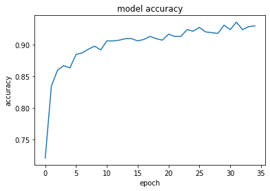

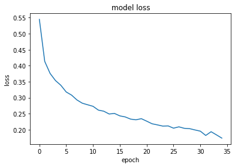

```python
from tensorflow import keras

modelB=keras.models.Sequential()
modelB.add(keras.layers.Dense(15, activation='relu',input_dim=15))
modelB.add(keras.layers.Dense(13, activation='relu'))
modelB.add(keras.layers.Dense(11, activation='relu'))
modelB.add(keras.layers.Dense(7, activation='relu'))
modelB.add(keras.layers.Dense(5, activation='relu'))
modelB.add(keras.layers.Dense(3, activation='relu'))
modelB.add(keras.layers.Dense(1, activation='sigmoid'))

modelB.compile(loss='binary_crossentropy',
              optimizer='adam',
              metrics=['accuracy'])

history=modelB.fit(X_train_final,y_train,epochs=35,batch_size=2,verbose=0)
learning_curve_nn(history)
```

Notre réseau est construit et entraîné, on peut donc prédire nos données.

```
Accuracy: 0.84
Précision: 0.76
Sensitivité: 0.78
F1: 0.77
```

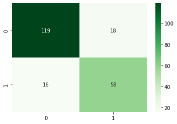

```python
nnB_pred=np.round(modelB.predict(X_test_final),0) #On prédit nos données

dict_models_pred['nnB']=nnB_pred #On l'ajoute à notre dictionnaire

model_score(y_test,nnB_pred) #Score
matrice_conf(y_test,nnB_pred) #Matrice de confusion
```

Même chose pour la base de données splines.

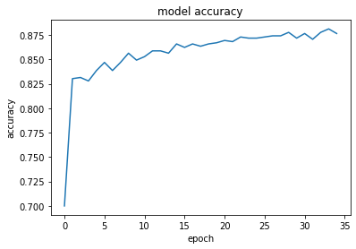

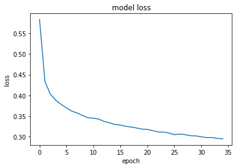

```python
modelS=keras.models.Sequential()
modelS.add(keras.layers.Dense(15, activation='relu',input_dim=15))
modelB.add(keras.layers.Dense(13, activation='relu'))
modelB.add(keras.layers.Dense(11, activation='relu'))
modelB.add(keras.layers.Dense(7, activation='relu'))
modelB.add(keras.layers.Dense(5, activation='relu'))
modelB.add(keras.layers.Dense(3, activation='relu'))
modelS.add(keras.layers.Dense(1, activation='sigmoid'))

modelS.compile(loss='binary_crossentropy',
              optimizer='adam',
              metrics=['accuracy'])

history=modelS.fit(X_train_spline_final,y_train,epochs=35,batch_size=2,verbose=0)

learning_curve_nn(history)
```

```
Accuracy: 0.84
Précision: 0.77
Sensitivité: 0.78
F1: 0.78
```

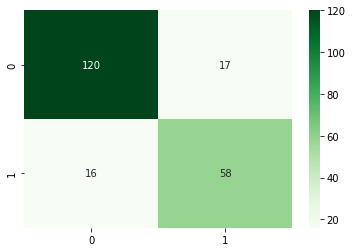

```python
nnS_pred=np.round(modelS.predict(X_test__spline_final),0) #On prédit nos données

dict_models_pred['nnS']=nnS_pred #On l'ajoute à notre dictionnaire

model_score(y_test,nnS_pred) #Score
matrice_conf(y_test,nnS_pred) #Matrice de confusion
```

### VotingClassifier

Un Voting Classifier est un modèle qui s'entraîne sur un ensemble de modèle et qui prédit une sortie en croisant les résultats des différents modèles (au vote majoritaire). On commence par la base de données normale en utilisant les modèles utilisées précédemment.

```
Accuracy: 0.85
Précision: 0.79
Sensitivité: 0.8
F1: 0.79
```

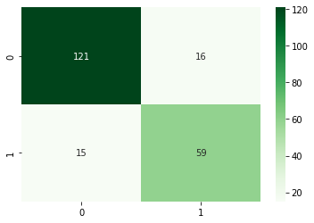

```python
from sklearn.ensemble import VotingClassifier

vcB = VotingClassifier( #On crée notre VotingClassifier
 estimators=[('logRegB',logRegB), ('rfB',rfB), ('knnB', knnB),('svmB',svmB),("adaB",adaB)],
    voting='hard')

vcB.fit(X_train_final,y_train) #On entraine notre modèle
vcB_pred =vcB.predict(X_test_final)# On prédit nos données

dict_models_pred['vcB']=vcB_pred  #On ajoute les résultats dans notre dictionnaire

model_score(y_test,vcB_pred) #Score
matrice_conf(y_test,vcB_pred) #Matrice de confusion
```

```
Accuracy: 0.84
Précision: 0.77
Sensitivité: 0.77
F1: 0.77
```

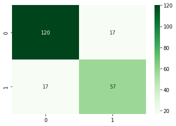

```python
vcS = VotingClassifier( #On crée notre VotingClassifier
 estimators=[('logRegS',logRegS), ('rfS',rfS), ('knnS', knnS),('svmS',svmS),("adaS",adaS)],
    voting='hard')

vcS.fit(X_train_final,y_train) #On entraine notre modèle
vcS_pred =vcS.predict(X_test_final)# On prédit nos données

dict_models_pred['vcS']=vcS_pred  #On ajoute les résultats dans notre dictionnaire

model_score(y_test,vcS_pred) #Score
matrice_conf(y_test,vcS_pred) #Matrice de confusion
```

# Sélection du modèle, optimisation et validation

On observe un récapitulatif de tout nos modèles avec leurs différents scores :

```python
recap_model(dict_models_pred,y_test)
```

|  | Accuracy | Precision | Sensitivity | Score F1 | Somme |
| --- | --- | --- | --- | --- | --- |
| knnB | 0.86 | 0.79 | 0.82 | 0.81 | 3.28 |
| adaB | 0.85 | 0.74 | 0.86 | 0.80 | 3.25 |
| adaS | 0.85 | 0.75 | 0.85 | 0.80 | 3.25 |
| vcB | 0.85 | 0.79 | 0.80 | 0.79 | 3.23 |
| logRegS | 0.86 | 0.82 | 0.76 | 0.79 | 3.23 |
| rfB | 0.85 | 0.78 | 0.81 | 0.79 | 3.23 |
| knnS | 0.86 | 0.81 | 0.77 | 0.79 | 3.23 |
| svmS | 0.86 | 0.82 | 0.76 | 0.79 | 3.23 |
| logRegB | 0.85 | 0.83 | 0.73 | 0.78 | 3.19 |
| rfS | 0.85 | 0.78 | 0.78 | 0.78 | 3.19 |
| nnS | 0.84 | 0.77 | 0.78 | 0.78 | 3.17 |
| nnB | 0.84 | 0.76 | 0.78 | 0.77 | 3.15 |
| vcS | 0.84 | 0.77 | 0.77 | 0.77 | 3.15 |
| svmB | 0.83 | 0.77 | 0.74 | 0.76 | 3.10 |

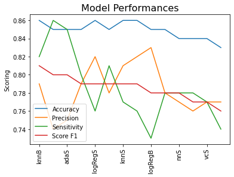

```python
result = recap_model(dict_models_pred,y_test).sort_values(by = "Somme", ascending = False)
res_cols = ["Accuracy","Precision","Sensitivity","Score F1"]
result[res_cols].plot()
plt.xticks(rotation=90)
plt.legend(res_cols)
plt.ylabel("Scoring")
plt.title("Model Performances", fontdict = {"fontsize": 16} );
```

Le meilleur modèle parmi tous ceux que l'on a testés semble être les k plus proches voisins sur les données normalisées.

On décide donc de retenir les KNN sur les données de base comme meilleur modèle. Maintenant qu'on a trouvé le meilleur modèle, il faut l'optimiser :

## Optimisation du modèle

La **validation croisée** (cross validation) consiste à découper notre data set en plusieurs parts égales et croiser différents processus d'apprentissage/test. Par exemple on divise les individus en 5 groupes A,B,C,D,E de taille égale. D'abord on entraîne le modèle sur A,B,C,D et on teste sur E. Puis on entraîne sur A,B,C,E et on teste sur D, et ainsi de suite. Finalement, on croise les résultats des 5 processus d'apprentissage/test. Cette technique, très souvent utilisée, permet d'avoir une estimation plus robuste de la validation du modèle.

On utilise **GridSearch** pour trouver les meilleurs hyperparamètres du modèle KNN. Un cross-valiation est effectué en même temps, ce qui rend les résultats plus robustes.

```python
l = []
a = metrics.accuracy_score(y_test,pred)
p = metrics.precision_score(y_test,pred)
s = metrics.recall_score(y_test,pred)
f = 2*(p*s)/(p+s)
new_metric = (a+p+s+f)
for i in range(2,17):
    gs = GridSearchCV(KNeighborsClassifier(), grid_params, verbose = 1, cv = i,n_jobs = -1)
    gs.fit(X_train_final,y_train)
    gs.best_params_
    pred = gs.predict(X_test_final)
    a = metrics.accuracy_score(y_test,pred)
    p = metrics.precision_score(y_test,pred)
    s = metrics.recall_score(y_test,pred)
    f = 2*(p*s)/(p+s)
    l.append(a+p+s+f)
```

```
Fitting 2 folds for each of 720 candidates, totalling 1440 fits
Fitting 3 folds for each of 720 candidates, totalling 2160 fits
Fitting 4 folds for each of 720 candidates, totalling 2880 fits
Fitting 5 folds for each of 720 candidates, totalling 3600 fits
Fitting 6 folds for each of 720 candidates, totalling 4320 fits
Fitting 7 folds for each of 720 candidates, totalling 5040 fits
Fitting 8 folds for each of 720 candidates, totalling 5760 fits
Fitting 9 folds for each of 720 candidates, totalling 6480 fits
Fitting 10 folds for each of 720 candidates, totalling 7200 fits
Fitting 11 folds for each of 720 candidates, totalling 7920 fits
Fitting 12 folds for each of 720 candidates, totalling 8640 fits
Fitting 13 folds for each of 720 candidates, totalling 9360 fits
Fitting 14 folds for each of 720 candidates, totalling 10080 fits
Fitting 15 folds for each of 720 candidates, totalling 10800 fits
Fitting 16 folds for each of 720 candidates, totalling 11520 fits
```

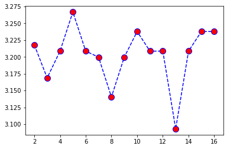

```python
plt.plot(range(2,17),l,color="blue",linestyle="dashed", marker="o",markerfacecolor="red", markersize=10)
```

```
Fitting 5 folds for each of 720 candidates, totalling 3600 fits
Accuracy: 0.86
Précision: 0.78
Sensitivité: 0.82
F1: 0.8
```

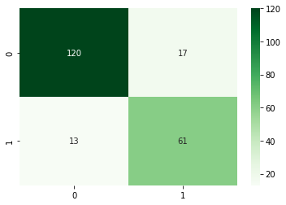

```python
gs = GridSearchCV(KNeighborsClassifier(), grid_params, verbose = 1, cv = 5,n_jobs = -1)
gs.fit(X_train_final,y_train)
pred = gs.predict(X_test_final)
knnG_pred = gs.predict(X_test_final)# On prédit nos données
dict_models_pred['knnG']=knnG_pred  #On ajoute les résultats dans notre dictionnaire
model_score(y_test,knnG_pred) #Score
matrice_conf(y_test,knnG_pred) #Matrice de confusion
```

```python
print("Les meilleurs paramètres sont:", gs.best_params_)
```

```
Les meilleurs paramètres sont: {'algorithm': 'auto', 'metric': 'manhattan', 'n_neighbors': 9, 'weights': 'distance'}
```

```python
recap_model(dict_models_pred,y_test)
```

|  | Accuracy | Precision | Sensitivity | Score F1 | Somme |
| --- | --- | --- | --- | --- | --- |
| knnB | 0.86 | 0.79 | 0.82 | 0.81 | 3.28 |
| knnG | 0.86 | 0.78 | 0.82 | 0.80 | 3.26 |
| adaB | 0.85 | 0.74 | 0.86 | 0.80 | 3.25 |
| adaS | 0.85 | 0.75 | 0.85 | 0.80 | 3.25 |
| vcB | 0.85 | 0.79 | 0.80 | 0.79 | 3.23 |
| logRegS | 0.86 | 0.82 | 0.76 | 0.79 | 3.23 |
| rfB | 0.85 | 0.78 | 0.81 | 0.79 | 3.23 |
| knnS | 0.86 | 0.81 | 0.77 | 0.79 | 3.23 |
| svmS | 0.86 | 0.82 | 0.76 | 0.79 | 3.23 |
| logRegB | 0.85 | 0.83 | 0.73 | 0.78 | 3.19 |
| rfS | 0.85 | 0.78 | 0.78 | 0.78 | 3.19 |
| nnS | 0.84 | 0.77 | 0.78 | 0.78 | 3.17 |
| nnB | 0.84 | 0.76 | 0.78 | 0.77 | 3.15 |
| vcS | 0.84 | 0.77 | 0.77 | 0.77 | 3.15 |
| knnF | 0.83 | 0.76 | 0.76 | 0.76 | 3.11 |
| svmB | 0.83 | 0.77 | 0.74 | 0.76 | 3.10 |

Le meilleur score pour la validation croisée est de 3.2, ce qui est inférieur au meilleur score (qui est de 3.28). La raison derrière cela est que la validation croisée effectuée lors de la recherche sur la grille ne tirera que de l'ensemble d'apprentissage en le divisant plusieurs fois en un nouvel ensemble d'apprentissage et un ensemble de validation. Par conséquent, le nombre d'observations sur lesquelles le modèle est réellement formé pour être optimisé est inférieur à celui d'avant. Cela se traduit par un score global inférieur, mais par une métrique de notation plus robuste, car le modèle est testé plusieurs fois dans plusieurs ensembles de tests différents à chaque étape de validation croisée.

La modèle optimal est donc les k plus proches voisins avec $k = 9$ et comme métrique la distance de Manhattan

## Modèle final

[output not shown]

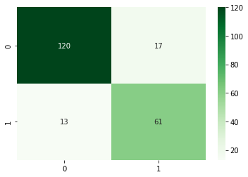

```python
{'algorithm': 'auto', 'metric': 'manhattan', 'n_neighbors': 9, 'weights': 'distance'}

knnF = KNeighborsClassifier(algorithm= 'auto', metric= 'manhattan', n_neighbors= 9,weights= 'distance')#On crée notre KNN
knnF.fit(X_train_spline_final,y_train) #On la fit à nos données
knnF_pred = knnF.predict(X_test__spline_final)# On prédit nos données

dict_models_pred['knnF']=knnF_pred  #On ajoute les résultats dans notre dictionnaire

model_score(y_test,knnF_pred) #Score
matrice_conf(y_test,knnF_pred) #Matrice de confusion
```

Les performances du modèle ne se sont pas améliorées avec l'exécution de Gridsearch. Cependant, la validation croisée utilisée dans le processus fournit un modèle plus robuste. On utilise donc le modèle ci-dessus comme modèle final

# Conclusion

Au cours de ce projet, nous avons pu tester de nombreux modèles de machine learning pour la classification supervisée : la régression logistique, la forêt aléatoire, les K plus proches voisins, le SVM linéaire, l'Adaboost, le Perceptron multicouche et le Voting classifier combinant les cinq premiers.

Cette étude nous a donc permis de construire, à partir des données du dataset "QSAR biodegradation", un modèle de classification binaire supervisée permettant de prédire assez efficacement si un composant chimique est biodégradable ou non.

Au passage, en effectuant le travail préliminaire sur les données, nous avons pu trouver quelles étaient les variables déterminant le plus le caractère biodégradable ou non des composants chimiques de notre dataset. N'ayant pas de formation avancée en chimie, nous ne nous sommes pas aventurés à tenter de donner une explication à ces résultats. Mais des personnes compétentes en la matière pourraient exploiter notre travail et apporter leur expertise en chimie pour expliquer nos résultats, afin de produire une analyse permettant de nourrir des travaux sur les questions de pollution environnementale.